# Evaluations of positive and negative stimuli using the Affective Misattribution Procedure (AMP) and self-reports

Analysis

Template: Ian Hussey; content: Tina Puskaric

09 Januar, 2024

# Dependencies

```r
library(tidyverse)
library(knitr)
library(kableExtra)
library(janitor)
library(scales)
# install.packages("ggmagnify", repos = c("https://hughjonesd.r-universe.dev",
#                 "https://cloud.r-project.org"))
library(ggmagnify)
library("ggExtra")
library("ggplot2")
library("viridis")
library("ggsci")
library(ggrepel)
library(ggridges)
library(patchwork)
library(easystats)
library(psych)
```

#SET.SEED

```r
set.seed(333)
```

# Data

- Load the processed data and apply the global exclusions.

```r
data_processed <- read_csv("../data/processed/data_processed.csv")

data_processed_after_exclusions <- data_processed |>
  filter(exclude_participant == "include")
```

# Sample descriptives

## Sample size before exclusions

```r
data_processed |>
  count(name = "n") |>
  kable() |>
  add_header_above(header = c("Whole sample" = 1)) |>
  kable_classic(full_width = FALSE)
```

| Whole sample n |
| --- |
| 102 |

## Sample size after exclusions

Sample used in subsequent analyses

```r
data_processed_after_exclusions |>
  count(name = "n") |>
  kable() |>
  add_header_above(header = c("For analysis" = 1)) |>
  kable_classic(full_width = FALSE)
```

| For analysis n |
| --- |
| 90 |

## Age

```r
data_processed_after_exclusions |>
  mutate(age = as.numeric(age)) |>
  summarise(Mean = mean(age, na.rm = TRUE),
            SD = sd(age, na.rm = TRUE)) |>
  mutate_all(.funs = janitor::round_half_up, digits = 1) |>
  kable() |>
  add_header_above(header = c("Age" = 2)) |>
  kable_classic(full_width = FALSE)
```

| Age Mean | Age SD |
| --- | --- |
| 36.8 | 12.4 |

## Gender

```r
data_processed_after_exclusions |>
  rename(Gender = gender) |>
  group_by(Gender) |>
  summarise(n = n()) |>
  mutate(Percent = paste0(round_half_up((n / sum(n)) * 100, 1), "%")) |>
  mutate(Gender = stringr::str_to_sentence(Gender)) |>
  kable() |>
  kable_classic(full_width = FALSE)
```

| Gender | n | Percent |
| --- | --- | --- |
| Female | 39 | 43.3% |
| Male | 48 | 53.3% |
| Nonbinary | 3 | 3.3% |

# Descriptives

Descriptive statistics and plots of the measures (excluding the demographics variables)

## Self-reported evaluations

### Cronbachs Alpha

raw alpha = 0.876904!

```r
library(psych)

alpha_result<-alpha(subset(data_processed_after_exclusions, select = c("like", "prefer", "positive")))
                    #, check.keys = T) for inverted items
print(alpha_result)
```

```
##
## Reliability analysis
## Call: alpha(x = subset(data_processed_after_exclusions, select = c("like",
##     "prefer", "positive")))
##
##   raw_alpha std.alpha G6(smc) average_r S/N   ase mean sd median_r
##       0.88      0.88    0.84      0.71 7.5 0.023  1.6  1     0.68
##
##     95% confidence boundaries
##          lower alpha upper
## Feldt     0.83  0.88  0.92
## Duhachek  0.83  0.88  0.92
##
##  Reliability if an item is dropped:
##          raw_alpha std.alpha G6(smc) average_r S/N alpha se var.r med.r
## like          0.81      0.81    0.68      0.68 4.2    0.040    NA  0.68
## prefer        0.79      0.80    0.67      0.67 4.0    0.043    NA  0.67
## positive      0.88      0.88    0.79      0.79 7.7    0.024    NA  0.79
##
##  Item statistics
##           n raw.r std.r r.cor r.drop mean  sd
## like     90  0.90  0.91  0.86   0.79  1.6 1.0
## prefer   90  0.91  0.92  0.87   0.80  1.7 1.1
## positive 90  0.88  0.87  0.75   0.71  1.7 1.2
##
## Non missing response frequency for each item
##             1    2    3    4    5    6    7 miss
## like     0.67 0.18 0.10 0.02 0.02 0.01 0.00    0
## prefer   0.67 0.12 0.11 0.07 0.03 0.00 0.00    0
## positive 0.68 0.16 0.07 0.07 0.00 0.02 0.01    0
```

### Descriptive stats

```r
# overall self-reported evaluations
dat_mean_ratings <- data_processed_after_exclusions |>
  summarise(Mean = mean(mean_evaluation, na.rm = TRUE),
            SD = sd(mean_evaluation, na.rm = TRUE),
            n = n()) |>
  mutate(group = "Full sample")

# self-reported evaluations by gender category
dat_mean_ratings_by_gender <- data_processed_after_exclusions |>
  group_by(group = gender) |>
  summarise(Mean = mean(mean_evaluation, na.rm = TRUE),
            SD = sd(mean_evaluation, na.rm = TRUE),
            n = n())

# combine both into one table
bind_rows(dat_mean_ratings,
          dat_mean_ratings_by_gender) |>
  select(Subset = group, Mean, SD, n) |>
  mutate(Subset = stringr::str_to_sentence(Subset)) |>
  mutate_if(is.numeric, round_half_up, digits = 2) |>
  kable() |>
  add_header_above(header = c(" " = 1, "Self-reported evaluations" = 3)) |>
  kable_classic(full_width = FALSE)
```

| Subset | Self-reported evaluations Mean | Self-reported evaluations SD | Self-reported evaluations n |
| --- | --- | --- | --- |
| Full sample | 1.64 | 1.02 | 90 |
| Female | 1.32 | 0.71 | 39 |
| Male | 1.81 | 1.03 | 48 |
| Nonbinary | 3.33 | 2.19 | 3 |

### Descriptive plot

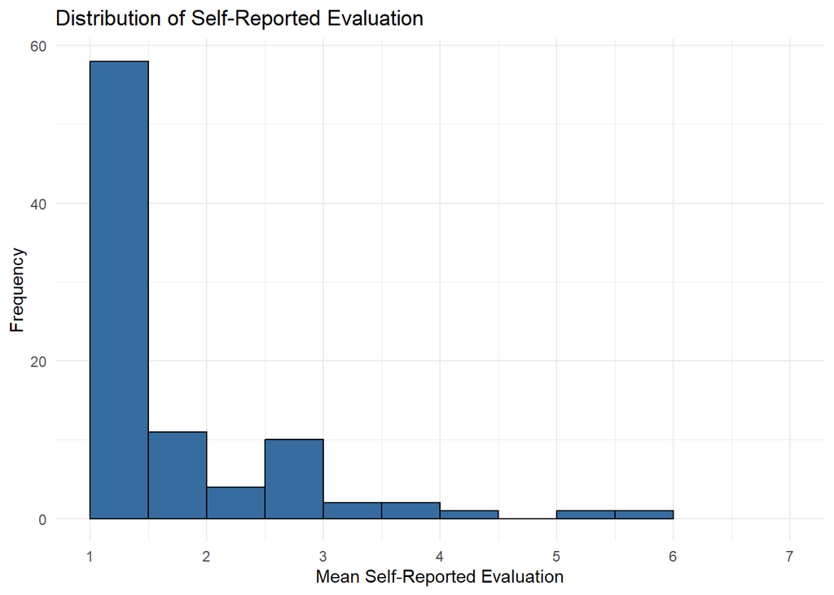

```r
ggplot(data_processed_after_exclusions, aes(x = mean_evaluation)) +
  geom_histogram(binwidth = 0.5,
                 boundary = 1,
                 fill = viridis_pal(begin = 0.45, option = "mako")(1),
                 color = "black") +
  labs(x = "Mean Self-Reported Evaluation",
       y ="Frequency",
       title = "Distribution of Self-Reported Evaluation ") +
  scale_x_continuous(breaks = pretty_breaks(n = 7)) +
  coord_cartesian(xlim = c(1, 7)) +
  theme(panel.grid.minor = element_blank()) +
  theme_minimal()
```

## AMP evaluations

### Descriptive stats

- add table of means, SDs, Ns

```r
# overall AMP scores
dat_AMP_means <- data_processed_after_exclusions |>
  summarise(Mean = mean(AMP_score, na.rm = TRUE),
            SD = sd(AMP_score, na.rm = TRUE),
            n = n()) |>
  mutate(group = "Full sample")

# AMP Scores by gender category
dat_AMP_by_gender <- data_processed_after_exclusions |>
  group_by(group = gender) |>
  summarise(Mean = mean(AMP_score, na.rm = TRUE),
            SD = sd(AMP_score, na.rm = TRUE),
            n = n())

# combine both into one table
bind_rows(dat_AMP_means,
          dat_AMP_by_gender) |>
  select(Subset = group, Mean, SD, n) |>
  mutate(Subset = stringr::str_to_sentence(Subset)) |>
  mutate_if(is.numeric, round_half_up, digits = 2) |>
  kable() |>
  add_header_above(header = c(" " = 1, "AMP Scores" = 3)) |>
  kable_classic(full_width = FALSE)
```

| Subset | AMP Scores Mean | AMP Scores SD | AMP Scores n |
| --- | --- | --- | --- |
| Full sample | 0.58 | 0.19 | 90 |
| Female | 0.58 | 0.21 | 39 |
| Male | 0.58 | 0.18 | 48 |
| Nonbinary | 0.55 | 0.06 | 3 |

### Descriptive plots

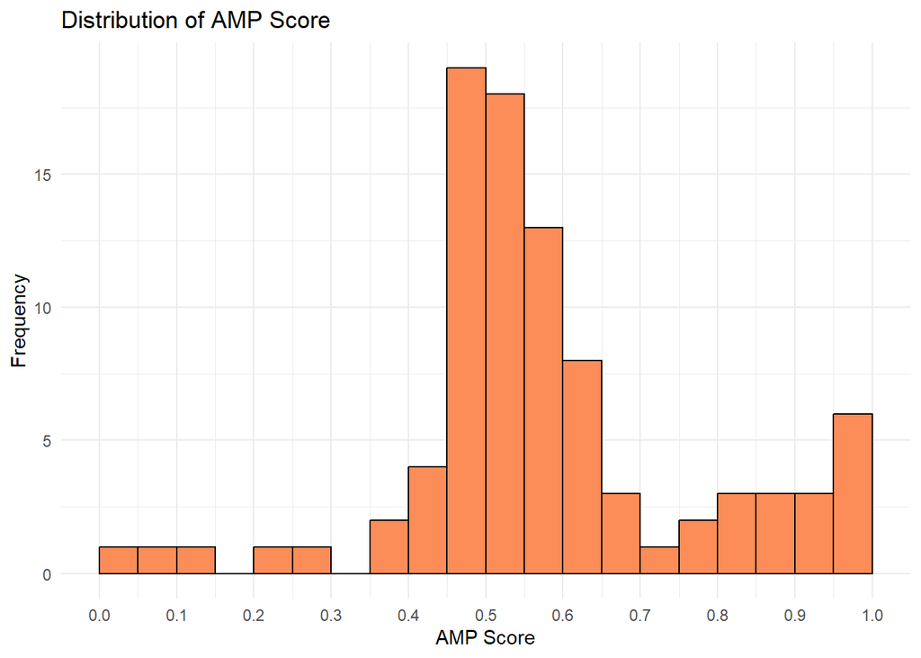

```r
#used a diffrent colour palette

ggplot(data_processed_after_exclusions, aes(x = AMP_score)) +
  geom_histogram(binwidth = 0.05,
                 boundary = 0,
                 fill = brewer_pal(palette = "Spectral")(1),
                 color = "black") +
  labs(x = "AMP Score",
       y = "Frequency",
       title = "Distribution of AMP Score") +
  scale_x_continuous(breaks = pretty_breaks(n = 10)) +
  theme_minimal()
```

# Analyses & hypothesis tests

## Self-reported evaluations are correlated with evaluations on the AMP

### Plot

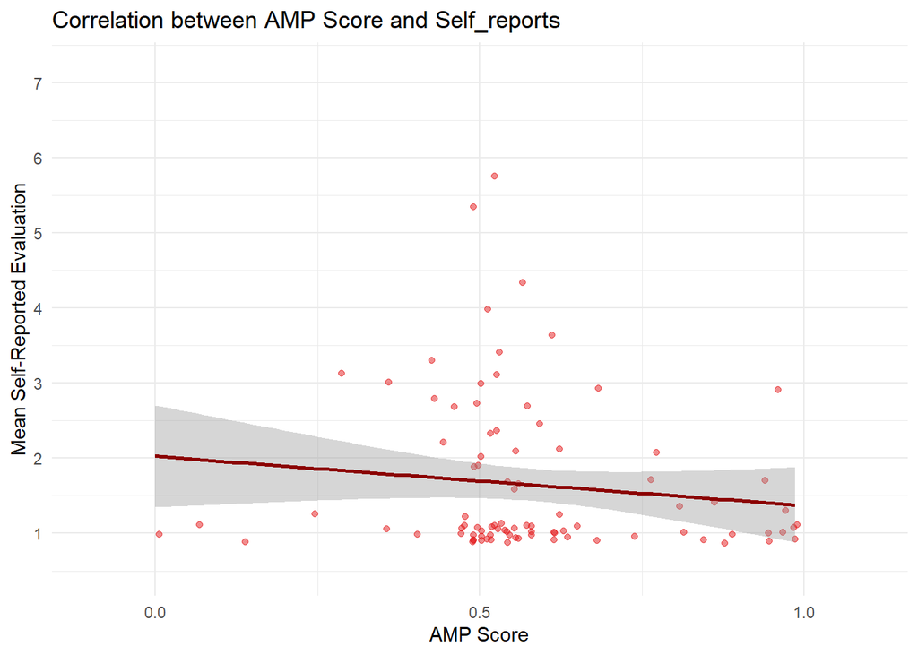

```r
ggplot(data_processed_after_exclusions,
       aes(x = AMP_score,
           y = mean_evaluation)) +
  geom_jitter(color = brewer_pal(palette = "Set1")(1),
              alpha = 0.5) +
  geom_smooth(method = "lm",
              color = "darkred") +
  labs(x = "AMP Score",
       y = "Mean Self-Reported Evaluation",
       title = "Correlation between AMP Score and Self_reports") +
  scale_y_continuous(limits = c(0.5, 7.2), breaks = c(1: 7)) +
  scale_x_continuous(limits = c(-0.1, 1.1), breaks = c(0, 0.5, 1)) +
  theme_minimal()
```

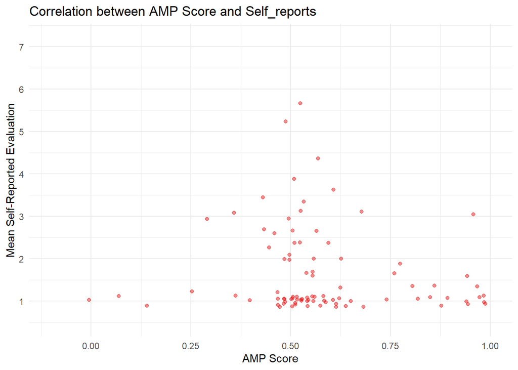

```r
#without the regression line
ggplot(data_processed_after_exclusions,
       aes(x = AMP_score,
           y = mean_evaluation)) +
  geom_jitter(color = brewer_pal(palette = "Set1")(1),
              alpha = 0.5) +
   labs(x = "AMP Score",
       y = "Mean Self-Reported Evaluation",
       title = "Correlation between AMP Score and Self_reports") +
  scale_y_continuous(limits = c(0.5, 7.2), breaks = c(1: 7)) +
  scale_x_continuous(limits = c(-0.1, 1)) +
  theme_minimal()
```

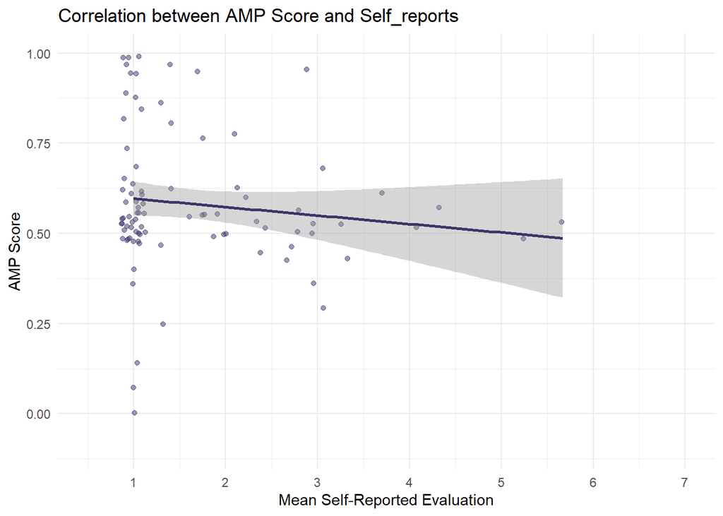

```r
#actually the same, but switched the X and Y Scale
ggplot(data_processed_after_exclusions,
       aes(y = AMP_score,
           x = mean_evaluation)) +
  geom_jitter(color = viridis_pal(begin = 0.25, option = "mako")(1),
              alpha = 0.5) +
  geom_smooth(method = "lm",
              color = viridis_pal(begin = 0.25, option = "mako")(1)) +
  labs(y = "AMP Score",
       x = "Mean Self-Reported Evaluation",
       title = "Correlation between AMP Score and Self_reports") +
  scale_x_continuous(limits = c(0.5, 7), breaks = c(1: 7)) +
  scale_y_continuous(limits = c(-0.1, 1)) +
  theme_minimal()
```

More complex plots:

#### Axial hisograms

Scatter plots with axial histograms using ggExtra: https://cran.r-project.org/web/packages/ggExtra/vignettes/ggExtra.html

- add axial histograms to a scatter plot. In a single plot, present different regression lines split by gender, and separate axial histograms for each gender.

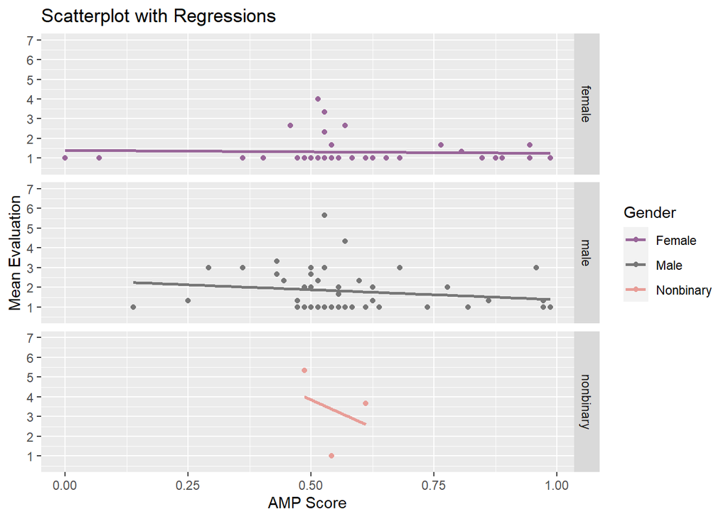

```r
#scatter Plots, with regression lines, without histograms - each single plot
ggplot(data_processed_after_exclusions, aes(AMP_score, mean_evaluation, colour = gender)) +
  geom_point() +
  scale_colour_manual(values = c("female"="#996699","male" = "#777777","nonbinary" =  "#e89d97"),
                      name = "Gender",
                      labels = c("Female", "Male", "Nonbinary"))+
  geom_smooth(method = "lm", se = FALSE) +
  facet_grid(gender ~ ., scales = "free_y", space = "free_y")+  #makes multiple plots
  labs(y = "Mean Evaluation",
       x = "AMP Score",
       title = "Scatterplot with Regressions") +
  scale_y_continuous(limits = c(0.5, 7), breaks = c(1: 7)) +
  theme_gray()
```

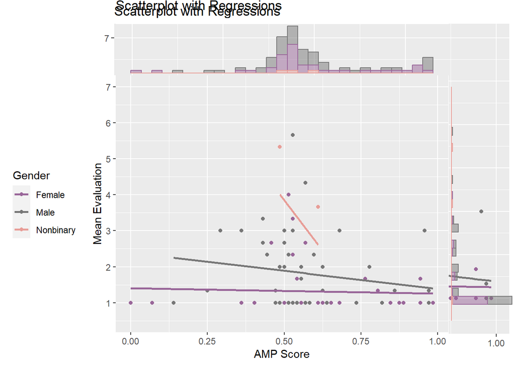

```r
#scatter Plots, with regression lines, without histograms - one plot
fr_MARG<- ggplot(data_processed_after_exclusions, aes(AMP_score, mean_evaluation, colour = gender)) +
  geom_point() +
 scale_colour_manual(values = c("female"="#996699","male" = "#777777","nonbinary" =  "#e89d97"),
                      name = "Gender",
                      labels = c("Female", "Male", "Nonbinary"))+
  geom_smooth(method = "lm", se = FALSE) +
  labs(y = "Mean Evaluation",
       x = "AMP Score",
       title = "Scatterplot with Regressions")+
  scale_y_continuous(limits = c(0.5, 7), breaks = c(1: 7)) +
   theme_gray() +
  theme(legend.position = "left")
print(fr_MARG)


#with histogramms above
#thats why the legend is on the left side
#it would look ugly if on the right side with the histogramms
ggMarginal(fr_MARG, type = "histogram", groupColour = TRUE, groupFill = TRUE)
```

#### Labelled points

Label points using ggrepel: https://cran.r-project.org/web/packages/ggrepel/vignettes/ggrepel.html

- Label the points in a scatter plot using their participant codes.

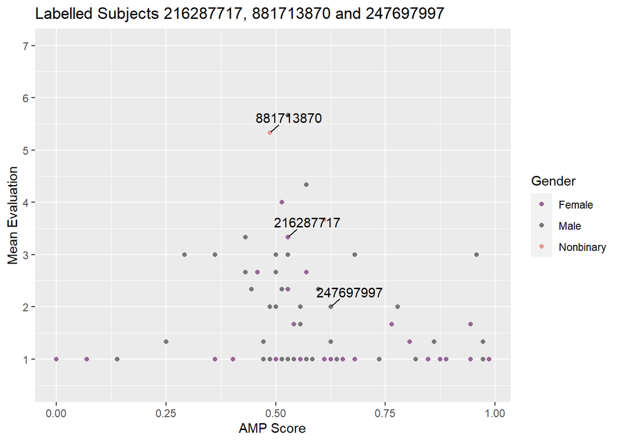

```r
#labelled with participant codes - 3 each one of a group
ggplot(data_processed_after_exclusions, aes(AMP_score, mean_evaluation, label = subject, colour = gender)) +
  geom_point() +
  geom_text_repel(data = subset(data_processed_after_exclusions, subject %in% c("216287717", "247697997", "881713870")),
                  aes(label = subject), color = "black", box.padding = 0.5) +
  scale_colour_manual(values = c("female"="#996699","male" = "#777777","nonbinary" =  "#e89d97"),
                      name = "Gender",
                      labels = c("Female", "Male", "Nonbinary")) +
  scale_y_continuous(limits = c(0.5, 7), breaks = c(1: 7)) +
  labs(title = "Labelled Subjects 216287717, 881713870 and 247697997",
       y = "Mean Evaluation",
       x = "AMP Score")
```

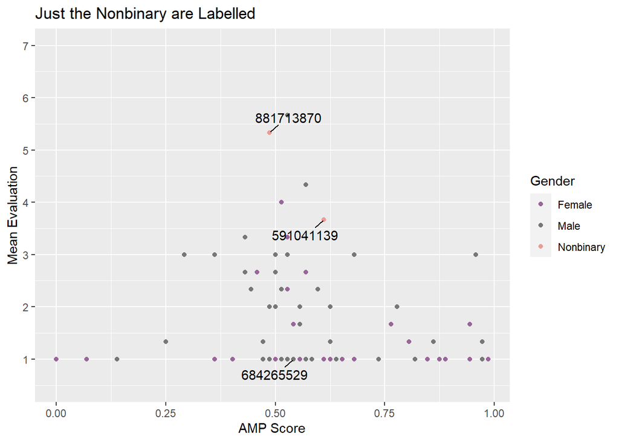

```r
#labelled one group - nonbinary
ggplot(data_processed_after_exclusions, aes(AMP_score, mean_evaluation, label = subject, colour = gender)) +
  geom_point() +
  geom_text_repel(data = subset(data_processed_after_exclusions, gender == "nonbinary"), aes(label = subject), color = "black", box.padding = 0.5) +
  scale_colour_manual(values = c("female"="#996699","male" = "#777777","nonbinary" =  "#e89d97"),
                      name = "Gender",
                      labels = c("Female", "Male", "Nonbinary")) +
  scale_y_continuous(limits = c(0.5, 7), breaks = c(1: 7)) +
  labs(title = "Just the Nonbinary are Labelled",
       y = "Mean Evaluation",
       x = "AMP Score")
```

Single Plots

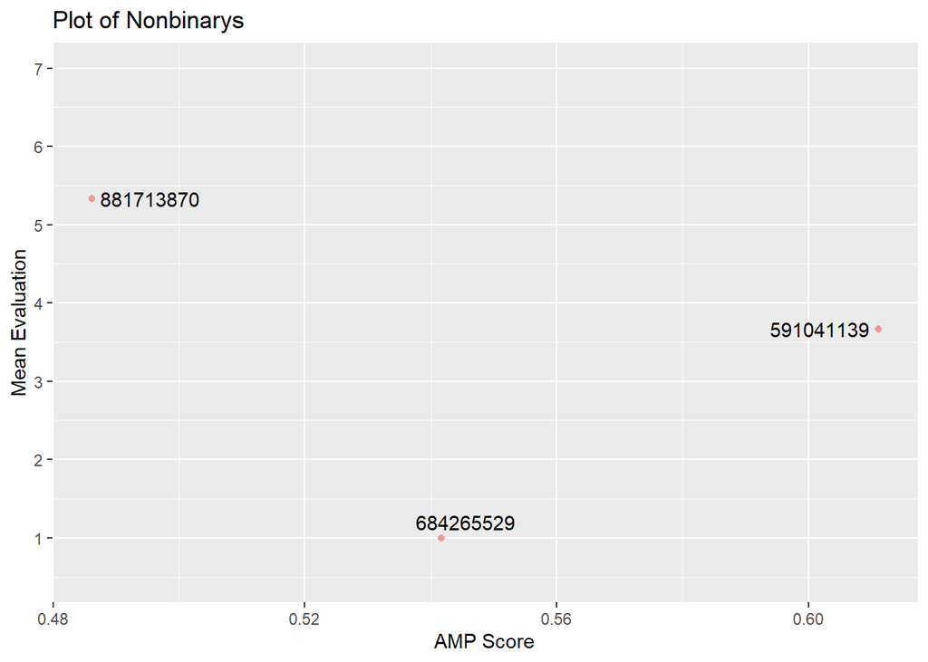

```r
#SINGLE PLOTS WITH LABELS!!!
#PREPARE DATASETS
data_p_a_e_nb <- data_processed_after_exclusions |>
  filter(gender == "nonbinary")

data_p_a_e_female <-data_processed_after_exclusions |>
  filter(gender == "female")

data_p_a_e_male <- data_processed_after_exclusions |>
  filter(gender == "male")


#for the Saving and Combine Task

#NONBINÄRY
p_label <- ggplot(data_p_a_e_nb, aes(AMP_score, mean_evaluation, label = subject)) +
  geom_point(color = "#e89d97")+
  scale_y_continuous(limits = c(0.5, 7), breaks = c(1: 7)) +
  labs(y = "Mean Evaluation",
       x = "AMP Score") +
  labs(title = "Plot of Nonbinarys") +
  theme_gray()

p_label + geom_text_repel()
```

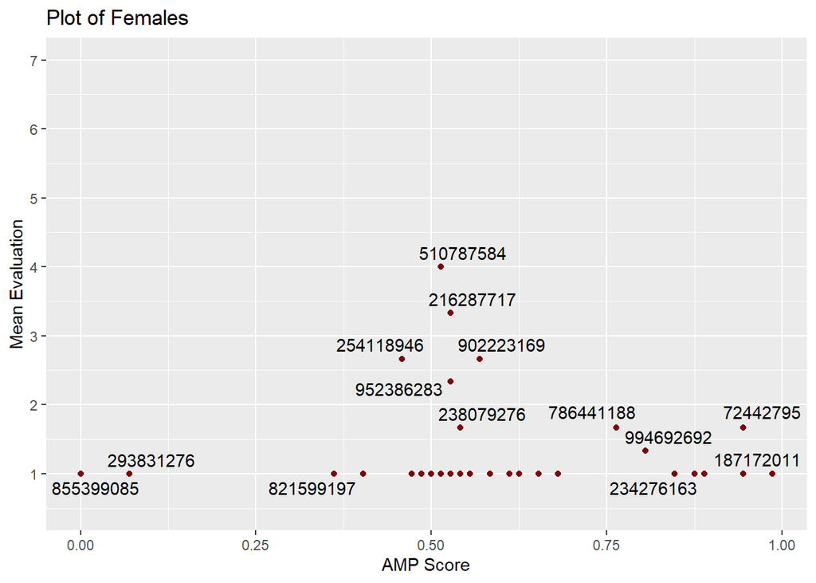

```r
#FEMALE - to many overlaps
p_f_label <- ggplot(data_p_a_e_female, aes(AMP_score, mean_evaluation, label = subject)) +
  geom_point(color = "#7a060a")+
  scale_y_continuous(limits = c(0.5, 7), breaks = c(1: 7)) +
  labs(y = "Mean Evaluation",
       x = "AMP Score") +
  labs(title = "Plot of Females") +
  theme_gray()

p_f_label + geom_text_repel()
```

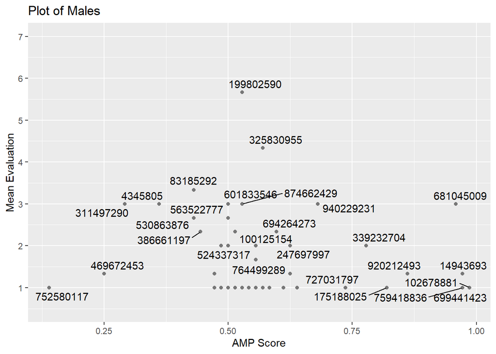

```r
#MALE - to many overlaps
p_m_label <- ggplot(data_p_a_e_male, aes(AMP_score, mean_evaluation, label = subject)) +
  geom_point(color = "#777777")+
  scale_y_continuous(limits = c(0.5, 7), breaks = c(1: 7)) +
  labs(y = "Mean Evaluation",
       x = "AMP Score") +
  labs(title = "Plot of Males") +
  theme_gray()

p_m_label + geom_text_repel()
```

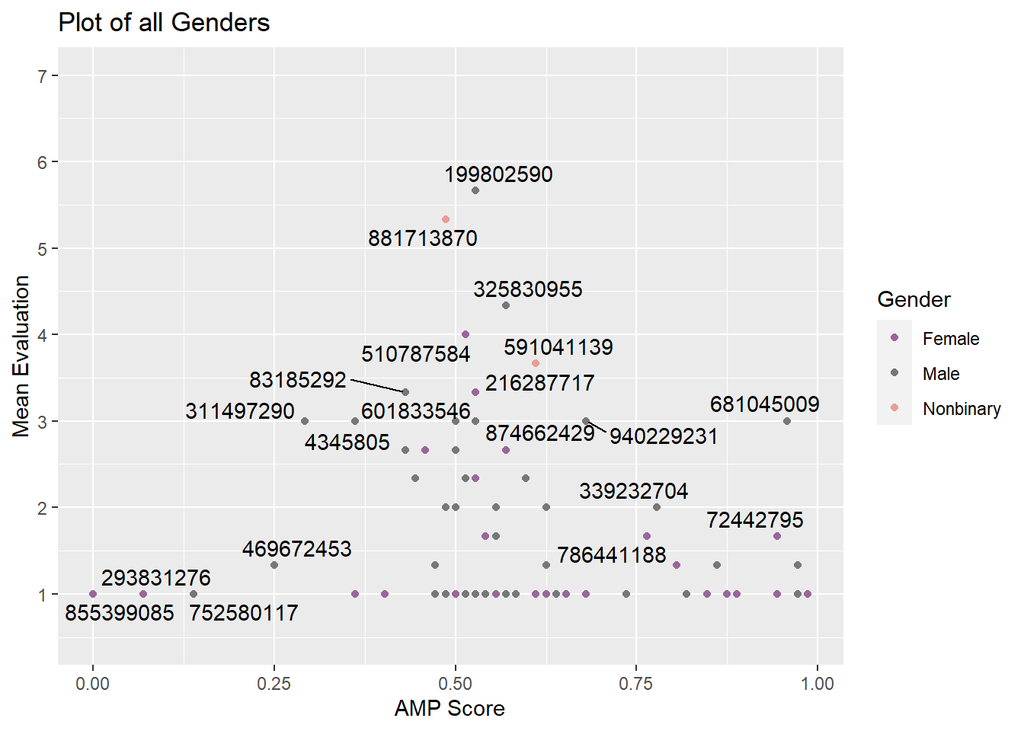

```r
#ALL

p_all_label <-ggplot(data_processed_after_exclusions, aes(AMP_score, mean_evaluation, label = subject, colour = gender)) +
  geom_point() +
   scale_colour_manual(values = c("female"="#996699","male" = "#777777","nonbinary" =  "#e89d97"),
                      name = "Gender",
                      labels = c("Female", "Male", "Nonbinary")) +
  scale_y_continuous(limits = c(0.5, 7), breaks = c(1: 7)) +
  labs(title = "Plot of all Genders",
      y = "Mean Evaluation",
       x = "AMP Score") +
  theme_gray()

p_all_label +geom_text_repel(color = "black")
```

#### Magnify areas

Magnify areas of your plot with ggmagnify: https://hughjonesd.github.io/ggmagnify/

- Magnify an area of one of your scatter plots, eg where there are a lot of data points in a small area.

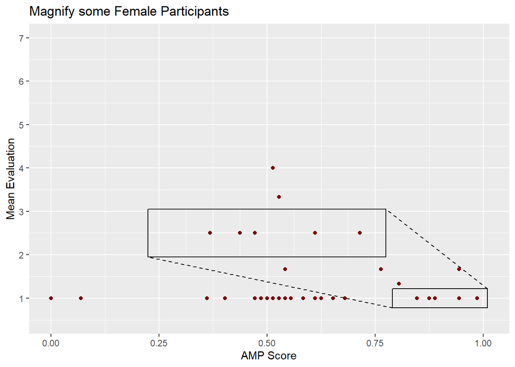

```r
#FEMALE - to many overlaps

from <- c(xmin =0.8,xmax = 1, ymin = 0.8, ymax = 1.2)
# Names xmin, xmax, ymin, ymax are optional:
to <- c(0.25,0.75, 2,3)

p_f_label + geom_magnify(from = from, to = to)+
    labs(title = "Magnify some Female Participants")
```

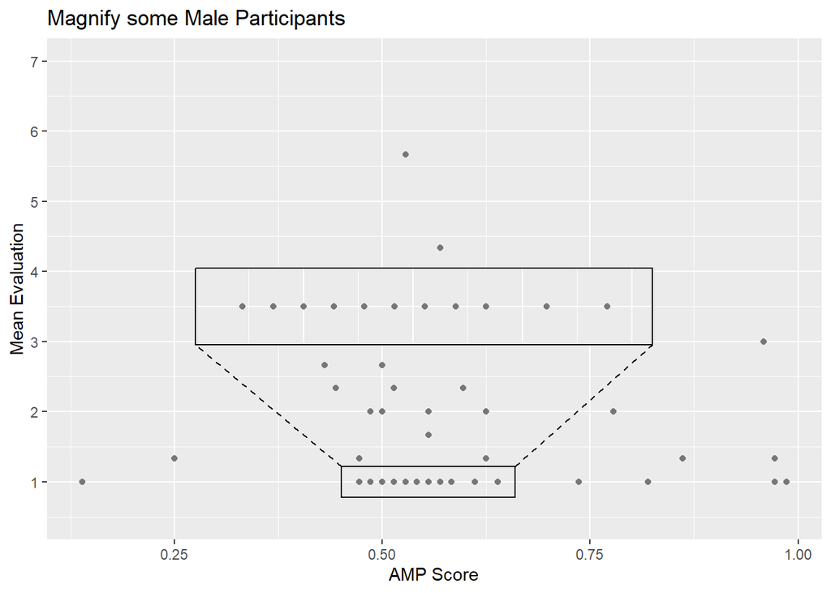

```r
#or

p_m_label + geom_magnify(from = c(0.46, 0.65, 0.8,  1.2), to = c(0.3,0.8, 3,4))+
   labs(title = "Magnify some Male Participants")
```

```r
#nonbinary to magnify would be a bit sad, because they are just three people
```

### Test

- run an appropriate test. Below the output, interpret the results. Consider using `easystats::report()`, but you can do this manually if you prefer.

```r
#remotes::install_github("easystats/report") <- something did go wrong


#The Pearson's product-moment correlation shows a negative correlation between AMP Score and Mean evaluation (r = -0.12, 95% CI [-0.32, 0.09]), but this is not statistically significant due to the relatively high p-value (t(88) = -1.17, p = 0.244), Accordingly, I would assume that there is no correlation between mean evaluation and the AMP score.



#I did a Correlation between mean_evaluation and AMP_score
Correlation <- cor(data_processed_after_exclusions$mean_evaluation, data_processed_after_exclusions$AMP_score)|>
  print()
```

```
## [1] -0.124196
```

```r
#some additional tests
correlation_test <- cor.test(data_processed_after_exclusions$mean_evaluation, data_processed_after_exclusions$AMP_score)|>
  print()
```

```
##
##  Pearson's product-moment correlation
##
## data:  data_processed_after_exclusions$mean_evaluation and data_processed_after_exclusions$AMP_score
## t = -1.1742, df = 88, p-value = 0.2435
## alternative hypothesis: true correlation is not equal to 0
## 95 percent confidence interval:
##  -0.32298009  0.08508347
## sample estimates:
##       cor
## -0.124196
```

```r
#easystats::report() <- somehow this does not work, so I tried other stuff out

report_table(correlation_test)
```

```
## Pearson's product-moment correlation
##
## Parameter1                                      |                                Parameter2 |     r |        95% CI | t(88) |     p
## -----------------------------------------------------------------------------------------------------------------------------------
## data_processed_after_exclusions$mean_evaluation | data_processed_after_exclusions$AMP_score | -0.12 | [-0.32, 0.09] | -1.17 | 0.244
##
## Alternative hypothesis: two.sided
```

```r
report_effectsize(correlation_test)
```

```
## Effect sizes were labelled following Funder's (2019) recommendations.
##
## small (r = -0.12, 95% CI [-0.32, 0.09])
```

```r
#for fun and to try out
report_table(data_processed_after_exclusions$mean_evaluation)
```

```
## Mean |   SD | Median |  MAD |  Min |  Max | n_Obs | Skewness | Kurtosis | n_Missing
## -----------------------------------------------------------------------------------
## 1.64 | 1.02 |   1.00 | 0.00 | 1.00 | 5.67 |    90 |     1.87 |     3.56 |         0
```

```r
report_table(data_processed_after_exclusions$AMP_score)
```

```
## Mean |   SD | Median |  MAD |  Min |  Max | n_Obs | Skewness | Kurtosis | n_Missing
## -----------------------------------------------------------------------------------
## 0.58 | 0.19 |   0.54 | 0.09 | 0.00 | 0.99 |    90 |     0.19 |     1.09 |         0
```

```r
report_statistics(correlation_test, table = NULL)
```

```
## r = -0.12, 95% CI [-0.32, 0.09], t(88) = -1.17, p = 0.244
```

```r
report_parameters(correlation_test)
```

```
##   - negative, statistically not significant, and small (r = -0.12, 95% CI [-0.32, 0.09], t(88) = -1.17, p = 0.244)
```

```r
#
```

## Self-reported evalautions differ between men and women

```r
# Prepare the data
data_p_e_without_nb <- data_processed_after_exclusions %>%
    filter(gender %in% c("female", "male"))


#t test
t_test_result <- t.test(mean_evaluation ~ gender, data = data_p_e_without_nb)
print(t_test_result)
```

```
##
##  Welch Two Sample t-test
##
## data:  mean_evaluation by gender
## t = -2.616, df = 83.137, p-value = 0.01056
## alternative hypothesis: true difference in means between group female and group male is not equal to 0
## 95 percent confidence interval:
##  -0.8613407 -0.1172918
## sample estimates:
## mean in group female   mean in group male
##             1.316239             1.805556
```

```r
#for interpreatation and report see below -> #Test
```

### Plot

- split histogram, split violin plot, raincloud plot, etc.

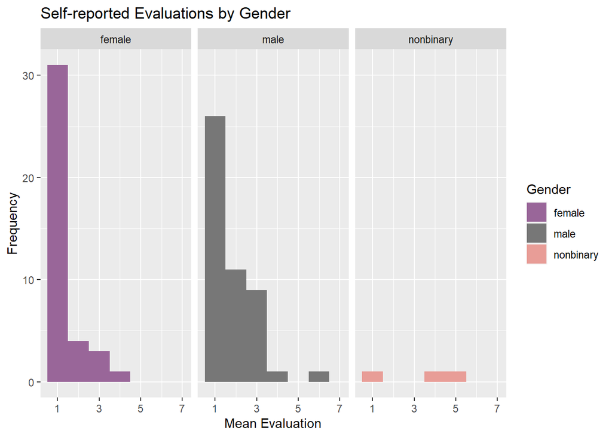

```r
#Split Histogram
ggplot(data_processed_after_exclusions,
       aes(x = mean_evaluation, group= gender, fill = gender)) +
  facet_grid(~gender)+
  geom_histogram(binwidth = 1) +
  scale_x_continuous(limits = c(0.5, 7.1), breaks = c(1,3,5,7)) +
  labs(title = "Self-reported Evaluations by Gender",
       x = "Mean Evaluation",
       y = "Frequency") +
  scale_fill_manual(values = c("female"="#996699","male" = "#777777","nonbinary" = "#e89d97"),
                    name = "Gender",
                    labels = c("female", "male", "nonbinary"))+
    theme_gray()
```

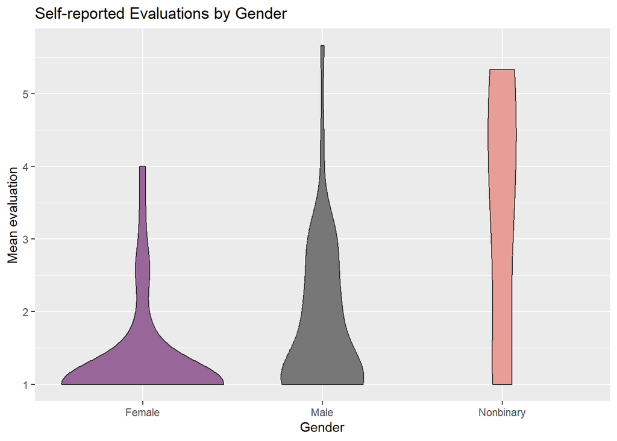

```r
#Split Violin
ggplot(data_processed_after_exclusions,
       aes(y = mean_evaluation, x = gender, fill =gender)) +
  geom_violin(show.legend = FALSE) +
  labs(title = "Self-reported Evaluations by Gender",
       y = "Mean evaluation",
       x = "Gender")+
  scale_fill_manual(values = c("female"="#996699","male" = "#777777","nonbinary" = "#e89d97"))+
  scale_x_discrete(labels = c("female" = "Female", "male" = "Male", "nonbinary" = "Nonbinary"))+
    theme_gray()
```

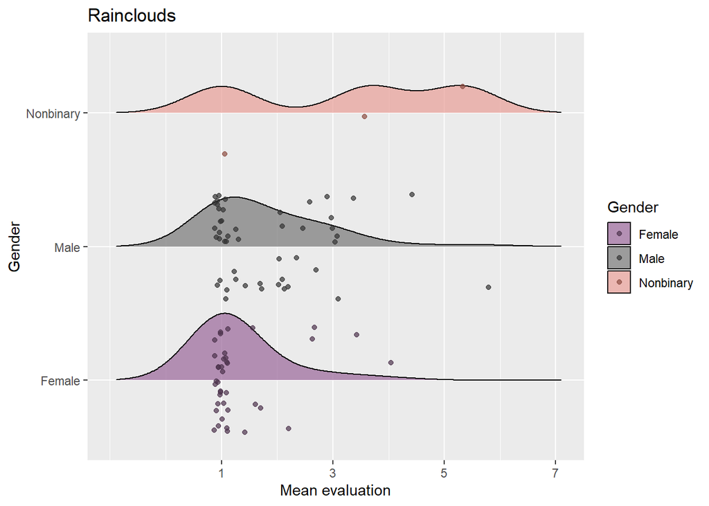

```r
#raincloud plot
  ggplot(data_processed_after_exclusions, aes(y = gender, x = mean_evaluation, fill = gender)) +
  geom_density_ridges(alpha = 0.7, scale = 0.5) +
  geom_point(position = position_jitter(), alpha = 0.7, aes(color = gender)) +
  scale_fill_manual(values = c("female" = "#996699", "male" = "#777777", "nonbinary" = "#e89d97"),
                    name = "Gender",
                    labels = c("Female", "Male", "Nonbinary")) +
  scale_color_manual(values = c("female" = "#4d334d", "male" = "#333333", "nonbinary" = "#8c4d42"),
                     name = "Gender",
                    labels = c("Female", "Male", "Nonbinary")) +
  scale_y_discrete(labels = c("female" = "Female", "male" = "Male", "nonbinary" = "Nonbinary"))+
  labs(title = "Rainclouds",
       x = "Mean evaluation",
       y = "Gender") +
  scale_x_continuous(limits = c(-1, 7.1), breaks = c(1,3,5,7)) +
    theme_gray()
```

```r
#von unten nach oben!
```

### Test

- run an appropriate test. Below the output, interpret the results: write a few sentences that report and interpret the results following APA reporting style.

```r
#A Welch Two Sample t-test was conducted to examine the mean evaluation between men and women. The women achieved a mean of 1.32 and the men a mean of 1.81. The mean difference is estimated to be -0.49 (95% CI [-0.86, -0.12]), indicating that, on average, male participants scored higher than the female participants. The t-statistic is indicative of a significant difference (t(83.14) = -2.62, p = 0.011). The effect size, measured by Cohen's d, is medium (-0.57, 95% CI [-1.01, -0.13]).
#These results show that there is a significant difference between men and women in terms of their mean evaluation scores, men gave higher scores on the scales than women.


report_table(t_test_result)
```

```
## Welch Two Sample t-test
##
## Parameter       |  Group | Mean_Group1 | Mean_Group2 | Difference |         95% CI | t(83.14) |     p |     d |          d  CI
## ------------------------------------------------------------------------------------------------------------------------------
## mean_evaluation | gender |        1.32 |        1.81 |      -0.49 | [-0.86, -0.12] |    -2.62 | 0.011 | -0.57 | [-1.01, -0.13]
##
## Alternative hypothesis: two.sided
```

```r
report_effectsize(t_test_result)
```

```
## Effect sizes were labelled following Cohen's (1988) recommendations.
##
## medium (Cohen's d = -0.57, 95% CI [-1.01, -0.13])
```

```r
# T TEST
```

## Evaluations on the Affect Misattribution Procedure differ between men and women

### Plot

- split histogram, split violin plot, raincloud plot, etc.
- This time, vary the labeling and order of the legend, e.g., capitalise “Men” and “Women”, and know how to change the order of the factors.

I made some Titles Bold

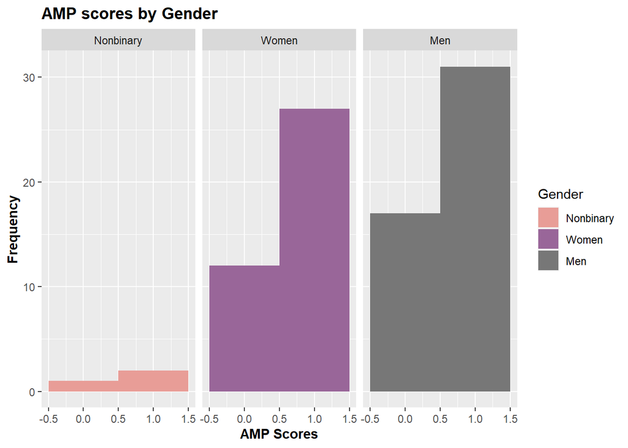

```r
#REARRANGE the order of the factors <- one way
data_p_a_e_rearranged <- data_processed_after_exclusions |>
  mutate(gender = factor(gender, levels = c("nonbinary", "female", "male")))
#other way with aes(y = , x = factor(VARIABLE, levels = c("order")...is soetimes more complicated


#Split Histogram
ggplot(data_p_a_e_rearranged,
       aes(x = AMP_score, group= gender, fill = gender)) +
   facet_grid(~gender, labeller = labeller(gender = c("nonbinary" = "Nonbinary", "female" = "Women", "male" = "Men"))) +
  geom_histogram(binwidth = 1) +
  labs(title = "AMP scores by Gender",
       x = "AMP Scores",
       y = "Frequency",
       fill = "Gender") +
  scale_fill_manual(values = c("female"="#996699","male" = "#777777","nonbinary" = "#e89d97"),
                    breaks = c("nonbinary", "female",  "male"),
                    labels=c("Nonbinary", "Women", "Men")) +
  theme(axis.title.x = element_text(face = "bold"),
        axis.title.y = element_text(face = "bold"),
        legend.title = element_text(face = "plain"),
        plot.title = element_text(face = "bold"))
```

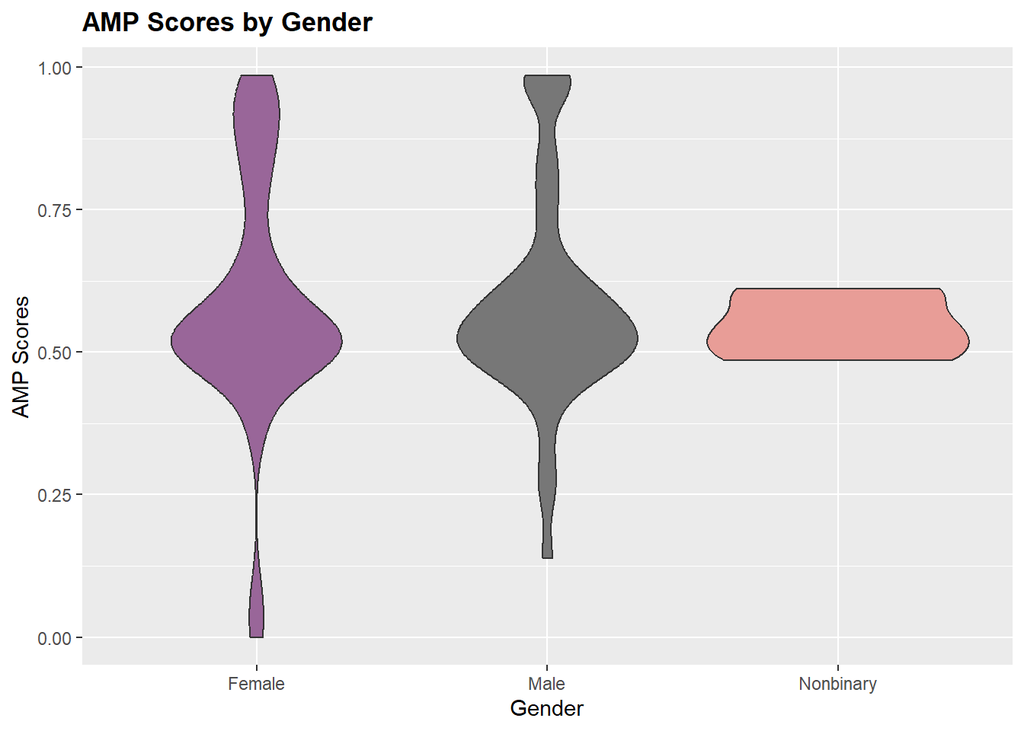

```r
#Split Violin rearrange in aes()
ggplot(data_p_a_e_rearranged,
       aes(y = AMP_score, x = factor(gender, levels = c("female", "male", "nonbinary")),
           fill = gender)) +
  geom_violin(show.legend = FALSE) +
  labs(title = "AMP Scores by Gender",
       y = "AMP Scores",
       x = "Gender",
       fill = "Gender") +
  scale_fill_manual(values = c("female" = "#996699", "male" = "#777777", "nonbinary" = "#e89d97"),
                    breaks = c("female", "male", "nonbinary")) +
  scale_x_discrete(labels = c("Female", "Male", "Nonbinary"))+
  theme(axis.title.x = element_text(face = "plain"),
        axis.title.y = element_text(face = "plain"),
        plot.title = element_text(face = "bold"))
```

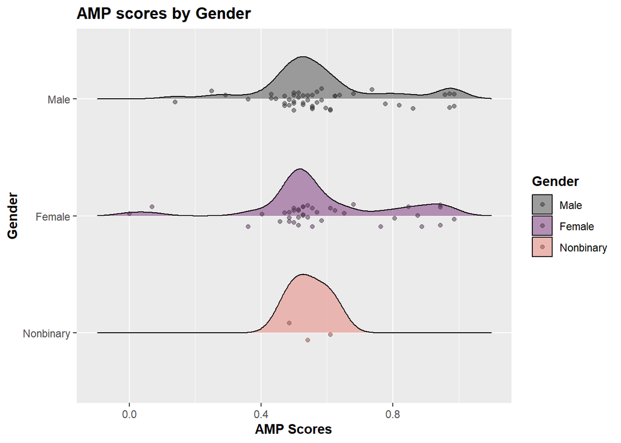

```r
#raincloud plot
ggplot(data_p_a_e_rearranged,
       aes(y = gender, x = AMP_score, fill = gender)) +
  geom_density_ridges(alpha = 0.7, scale = 0.5) +
    geom_jitter(position = position_jitterdodge(dodge.width = 0.2, jitter.width = 0.5),
              alpha = 0.5, aes(color = gender), show.legend = TRUE) +
  labs(title = "AMP scores by Gender",
       x = "AMP Scores",
       y = "Gender",
       fill ="Gender",
       color = "Gender") +
  scale_fill_manual(values = c("female" = "#996699", "male" = "#777777", "nonbinary" = "#e89d97"),
                    breaks = c("male", "female", "nonbinary"),
                    labels = c("Male", "Female", "Nonbinary")) +
  scale_color_manual(values = c("female" = "#4d334d", "male" = "#333333", "nonbinary" = "#8c4d42"),
                     breaks = c("male", "female", "nonbinary"),
                     labels = c("Male", "Female", "Nonbinary")) +
  scale_y_discrete(labels = c("Nonbinary", "Female", "Male")) +
  scale_x_continuous(limits = c(-0.1, 1.1)) +
  theme_gray()+
  theme(axis.title.x = element_text(face = "bold"),
        axis.title.y = element_text(face = "bold"),
        legend.title = element_text(face = "bold"),
        plot.title = element_text(face = "bold"))
```

### Test

- run an appropriate test. Below the output, print an interpretation of the results generated by the ‘easystats’ package [report](https://easystats.github.io/report/). I.e., use `report::report()`.

```r
#t test
AMP_t_test_result <- t.test(AMP_score ~ gender, data = data_p_e_without_nb)
print(AMP_t_test_result)
```

```
##
##  Welch Two Sample t-test
##
## data:  AMP_score by gender
## t = 0.073308, df = 76.079, p-value = 0.9418
## alternative hypothesis: true difference in means between group female and group male is not equal to 0
## 95 percent confidence interval:
##  -0.08270667  0.08902789
## sample estimates:
## mean in group female   mean in group male
##            0.5847578            0.5815972
```

```r
report_table(AMP_t_test_result)
```

```
## Welch Two Sample t-test
##
## Parameter |  Group | Mean_Group1 | Mean_Group2 | Difference |        95% CI | t(76.08) |     p |    d |         d  CI
## ---------------------------------------------------------------------------------------------------------------------
## AMP_score | gender |        0.58 |        0.58 |   3.16e-03 | [-0.08, 0.09] |     0.07 | 0.942 | 0.02 | [-0.43, 0.47]
##
## Alternative hypothesis: two.sided
```

```r
report_effectsize(AMP_t_test_result)
```

```
## Effect sizes were labelled following Cohen's (1988) recommendations.
##
## very small (Cohen's d = 0.02, 95% CI [-0.43, 0.47])
```

```r
#Interpretation
report_text(AMP_t_test_result)
```

```
## Effect sizes were labelled following Cohen's (1988) recommendations.
##
## The Welch Two Sample t-test testing the difference of AMP_score by gender (mean
## in group female = 0.58, mean in group male = 0.58) suggests that the effect is
## positive, statistically not significant, and very small (difference = 3.16e-03,
## 95% CI [-0.08, 0.09], t(76.08) = 0.07, p = 0.942; Cohen's d = 0.02, 95% CI
## [-0.43, 0.47])
```

```r
#The Welch Two Sample t-test testing the difference of AMP_score by gender (mean in group female =
#0.58, mean in group male = 0.58) suggests that the effect is positive, statistically not
#significant, and very small (difference = 3.16e-03, 95% CI [-0.08, 0.09], t(76.08) = 0.07, p =
#0.942; Cohen's d = 0.02, 95% CI [-0.43, 0.47])
```

## Combining plots

Combine plots using patchwork: https://patchwork.data-imaginist.com/

Combine at least three of the above plots into one.

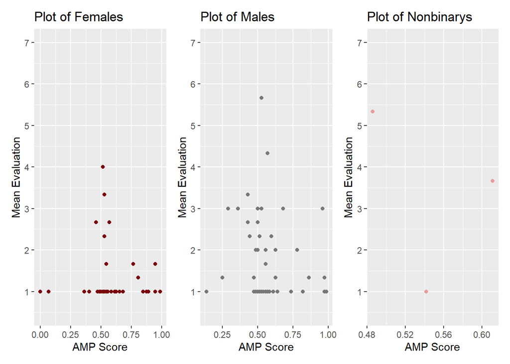

```r
#install.packages('patchwork')

#one varaiant
p_f_label + p_m_label + p_label
```

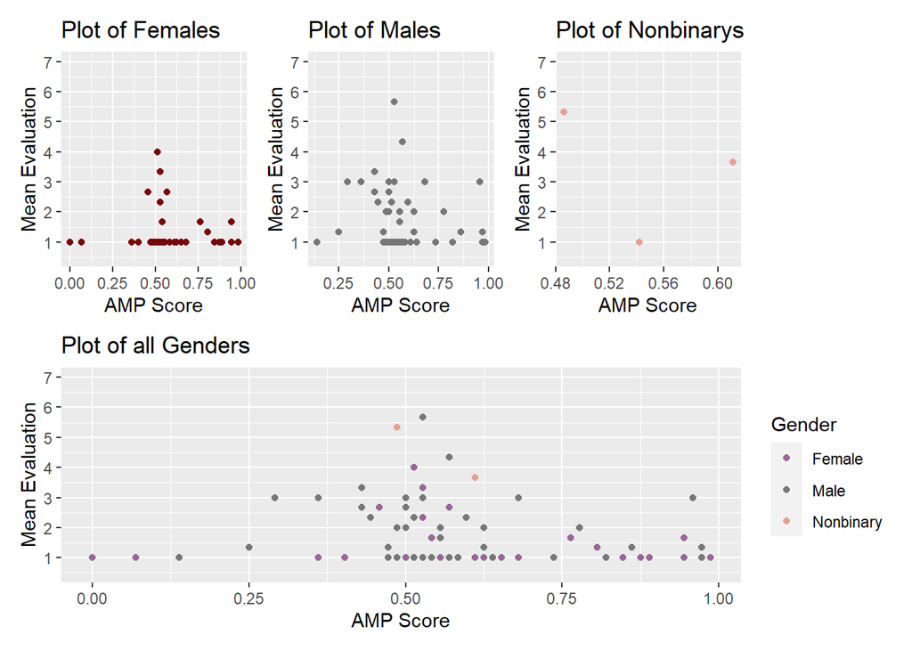

```r
#other variant
(p_f_label + p_m_label + p_label)/
  p_all_label
```

## Saving plots

Save plots to disk with `ggsave()`

- Save the above combined plot to disk as both .png and .pdf. Ensure the png has at least 300dpi resolution.

```r
to_save <- (p_f_label + p_m_label + p_label)/
  p_all_label



dir.create("../data/plots/")

ggsave("../data/plots/Gender_Comb_plot.png", plot = to_save, dpi = 300, device = "png")

ggsave("../data/plots/Gender_Comb_plot.pdf", plot = to_save, device = "pdf")
```

```r
#for reprocthings
```